# Using Data in Research

jmj

October 5, 2017

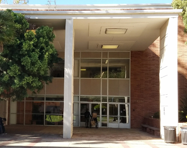

## Today’s Topics

In this session you will:

- Learn about the role of data in your research
- How to search for and access data for research
- Learn about resources, tools and support available to students and researchers at UCLA
- Data Management Plans

## UCLA Library Data Archives

#### (formally the Social Science Data Archive)

- On the UCLA campus since 1961 [About the Data Archive](https://www.library.ucla.edu/social-science-data-archive/about-data-archive)
- Available to all UCLA faculty and students
- Holdings include public opinion polls, census data, crime stats, political and social behavior, etc.

[figure not shown]

illustration: Rolfe Hall

https://www.library.ucla.edu/location/social-science-data-archive

## Role of Data in Research

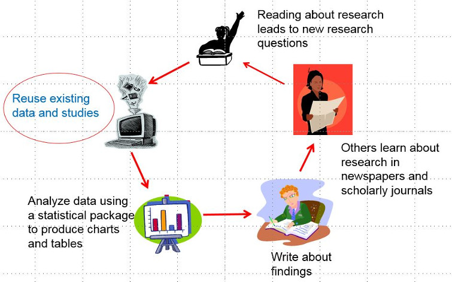

illustration: role of data in resaerch

## Finding Out About Data Sources

- UCLA Library Data Archive
- Colleagues
- Public media (newspapers, news)
- Social media (twitter, etc)
- Scholarly literature
- Government reports and documents
- Archives and project websites
- Codebooks, questionnaires

## Exploration of datasets

## Search Strategies and Defining Your Research

- General to specific; broad to narrow
- Names of investigators; names of studies
- Studies described in literature, news and websites

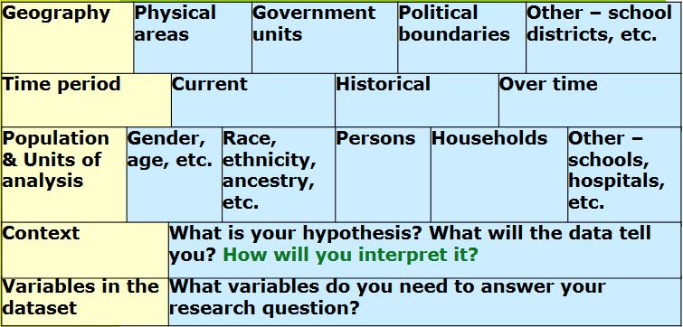

## How do I know this study useful?

- Raw data are **not** eye-readable
- To decipher data you will use **Questionnaires and Codebooks**

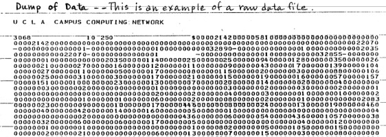

## What is a Questionnaire?

- A **questionnaire** is a *research instrument* consisting of a series of *questions* and other prompts for the purpose of gathering information from respondents.
- Questionnaires cover separate topics such as:
  - Preferences (e.g. political party)
  - Behaviors (e.g. food consumption)
  - Facts (e.g. gender)
- Questionnaires can include indexes or scales:
  - Latent traits (e.g. personality traits)
  - Attitudes (e.g. towards immigration)
  - An index (e.g. Social Economic Status)

## Questionnaire

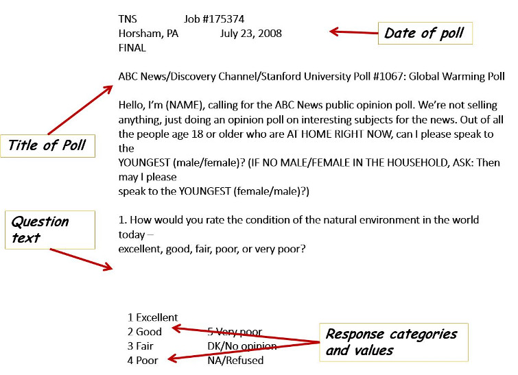

illustration: Questionnaire

## Codebooks: Example #1

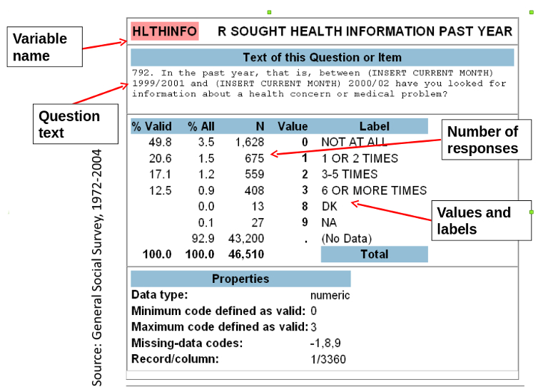

## ICPSR Data Site

#### Inter-university Consortium for Political and Social Research http://www.icpsr.umich.edu

[figure not shown]

illustration: ICPSR

## ICPSR: Register to Access Data

[figure not shown]

illustration: ICPSR Register

## ICPSR: Search by Topics

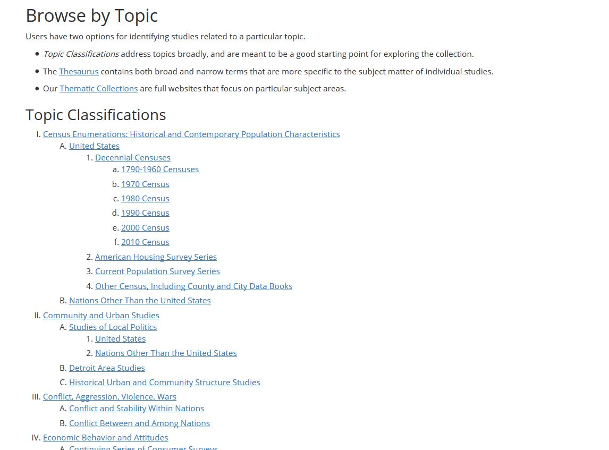

## ICPSR: Search for and Compare Variables

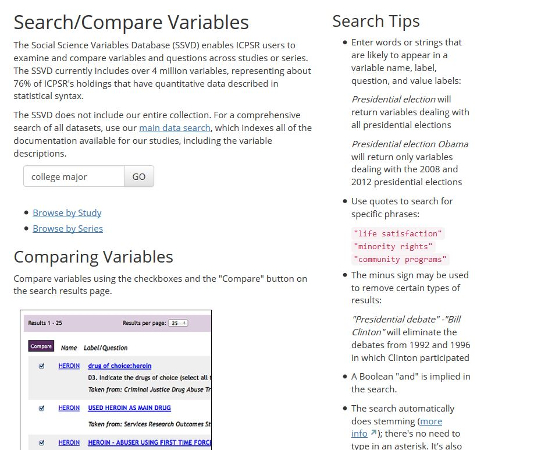

## ICPSR: Compare Variables

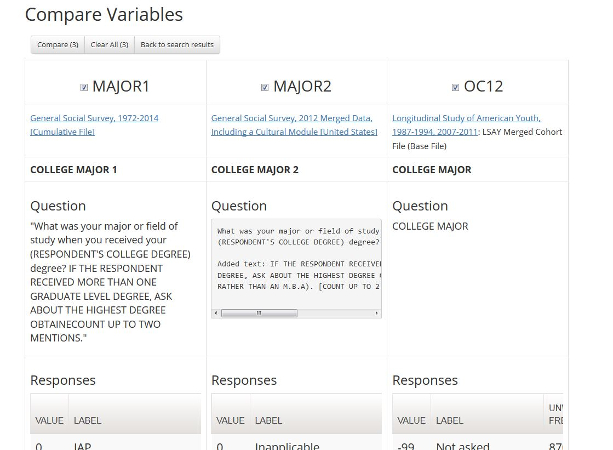

## ICPSR: Study Page and Data

[figure not shown]

## ICPSR: Reading About Data

[figure not shown]

## ICPSR: Publications linked to Data

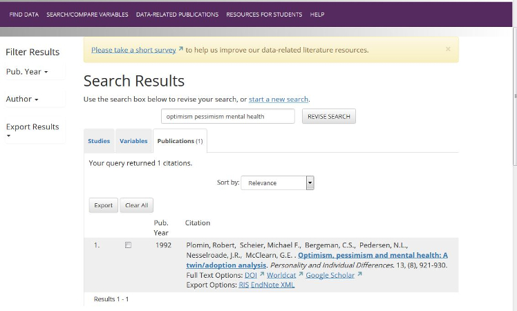

illustration: ICPSR Publications linked to Data

## ICPSR: Publications Linked to Data

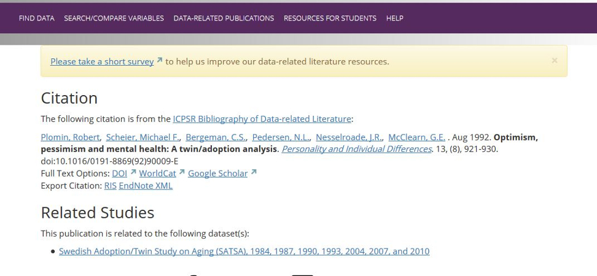

illustration: ICPSR Publications Linked to Data

## Data Sources

- ICPSR: http://www.icpsr.umich.edu/icpsrweb/ICPSR/
- UCLA Library Data Archive Catalog: https://dataverse.harvard.edu/dataverse/ssda_ucla
- Government Sites, Census Data: https://www.census.gov/
- IPUMS (Integrated Public Use Microdata Series): https://www.ipums.org/
- Public Policy Institute of CA: www.ppic.org
- NBER (National Bureau of Economic Research): http://www.nber.org/data/
- CDC/NCHS (Centers for Disease Control and Prevention/National Center for Health Statistics): https://www.cdc.gov/nchs/surveys.htm
- Pew Research Center: http://www.pewresearch.org/
- Data.gov: https://www.data.gov/

# Data Management Plans

- What is a Data Management Plans
- Why do I need this?
- What tools are available to help?

## What is a Data Management Plan?

A data management plan is a document that describes what you will do with your data *during* your research and *after* you complete your research.

## Why do you need this?

- Funding Agencies
- Publishing
- Sharing and Archiving Data
- Regardless of the requirements, good data management is an essential skill for researchers.

## Getting help

- Data Archive
- ICPSR

## Questions?

[figure not shown]

illustration: Questions

## Problems ?

## The Data Archive is here to help

1120-H Rolfe  
ucla-data-archive@googlegroups.com  
310-825-0716  
Tim Dennis, Director of the Data Archive  
Jamie Jamison, Archive Staff